# Домашняя работа №4

## 1. Задания из комментариев ноутбука

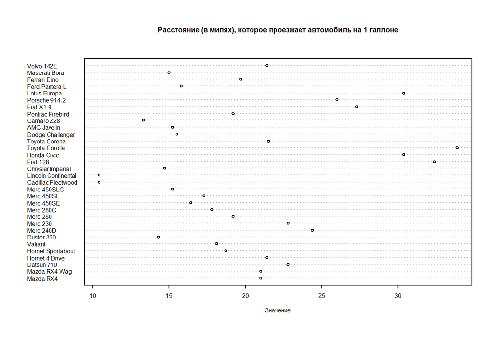

```r
data <- mtcars
dotchart(data$mpg, labels = row.names(data),
         main="Расстояние (в милях), которое проезжает автомобиль на 1 галлоне",
         xlab="Значение", cex = 0.5)
```

Перерисуем график для расхода топлива в литрах/км.

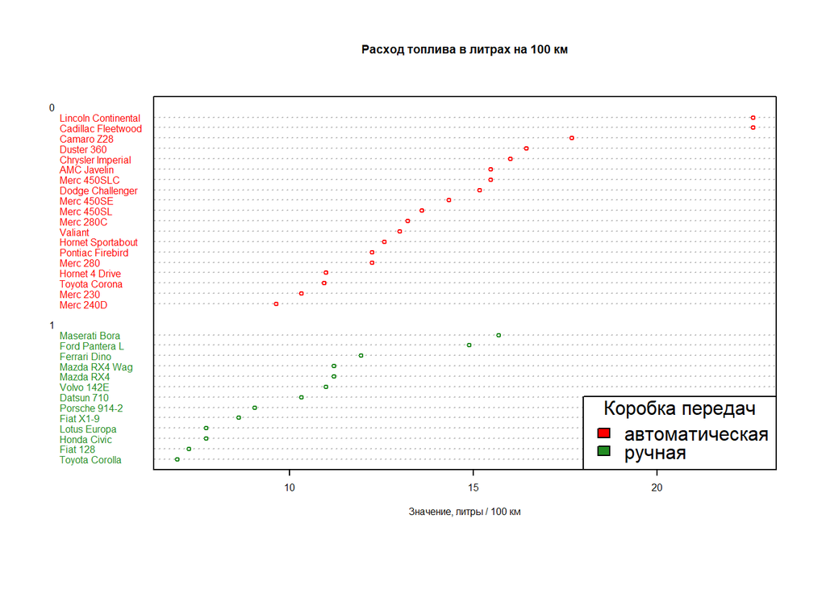

```r
# функция форматирования единиц измерения для расхода топлива
format_consumption <- function(miles_per_gallon) {
  km_per_litr <- 0.425144 * miles_per_gallon
  return(1 / km_per_litr)
}

# добавим новый признак - количество топлива в литрах, расходуемое на 1 км
data["lpkm"] <- format_consumption(data$mpg)

# Сделали фактор из типа коробки передач
data$am <- as.factor(data$am)

# Создали признак цвета в соответствии с типом коробки передач
data$color[data$am == 0] <- "red"
data$color[data$am == 1] <- "forestgreen"

# Упорядочили данные по признаку lpkm
ord_data <- data[order(data$lpkm),]

# Поскольку более естественная характеристика расхода топлива - количество литров на 100 км, нарисуем именно такой график (дополнительно сгруппируем данные по типу коробки передач):
dotchart(100 * ord_data$lpkm, row.names(ord_data), groups = ord_data$am,
         gcolor = "black", color = ord_data$color,
         main = "Расход топлива в литрах на 100 км",
         xlab = "Значение, литры / 100 км", cex = 0.5)
legend(x = "bottomright", title = "Коробка передач",
       legend = c("автоматическая", "ручная"),
       col = c("red", "forestgreen"), fill = c("red", "forestgreen"))
```

Из получившегося графика явно видно, что в среднем расход топлива у машин с автоматической коробкой передач выше, чем у машин с ручной.

Построим dotchart для признака disp (объем двигателя):

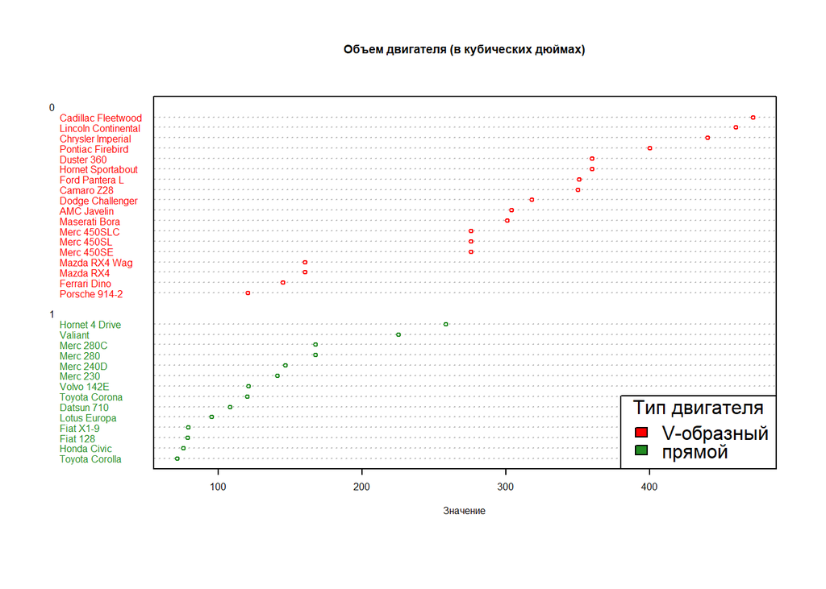

```r
data <- mtcars

# Сделали фактор из типа двигателя
data$vs <- as.factor(data$vs)

# Создали признак цвета в соответствии с типом коробки передач
data$color[data$vs == 0] <- "red"
data$color[data$vs == 1] <- "forestgreen"

# Упорядочили данные по признаку disp
ord_data <- data[order(data$disp),]

# Сгруппируем данные по типу двигателя:
dotchart(ord_data$disp, row.names(ord_data), groups = ord_data$vs,
         gcolor = "black", color = ord_data$color,
         main = "Объем двигателя (в кубических дюймах)",
         xlab = "Значение", cex = 0.5)
legend(x = "bottomright", title = "Тип двигателя",
       legend = c("V-образный", "прямой"),
       col = c("red", "forestgreen"), fill = c("red", "forestgreen"))
```

Из графика видно, что машины с V-образным двигателем в большинстве случаев имеют больший объем двигателя, чем с прямым, что можно объяснить соображениями компактности двигателя (если хотим больший объем двигателя, нет смысла наращивать цилиндры в длину)

# 2. Анализ выбранного датасета с помощью dotchart, boxplot и stripchart

Датасет содержит информацию о 12181 объявлении о продаже апартаментов в Москве. Каждое объявление представлено 22 числовыми и категориальными признаками, среди которых цена, оценка ремонта по шкале от 1 до 4, возраст дома, расстояние до ближайшей станции метро и соответствующее id станции, количество комнат, административный округ, метраж и другие.

```r
file <- file.choose()
my_data <- read.csv(file)
colnames(my_data)
```

```
##  [1] "price"                 "repair"                "year_built_empty"
##  [4] "house_age"             "closest_subway"        "dist_to_subway"
##  [7] "sg"                    "lat"                   "lon"
## [10] "subway_dist_to_center" "h3"                    "agent_offers"
## [13] "subway_offers"         "address_offers"        "rooms"
## [16] "footage"               "floor"                 "max_floor"
## [19] "first_floor"           "last_floor"            "AO"
## [22] "hm"
```

```r
my_data[, "AO"] <- as.factor(my_data$AO)
my_data[, "price"] <- as.vector(my_data$price)
```

```r
length(my_data$price) == length(my_data$AO)
```

```
## [1] TRUE
```

График dotchart:

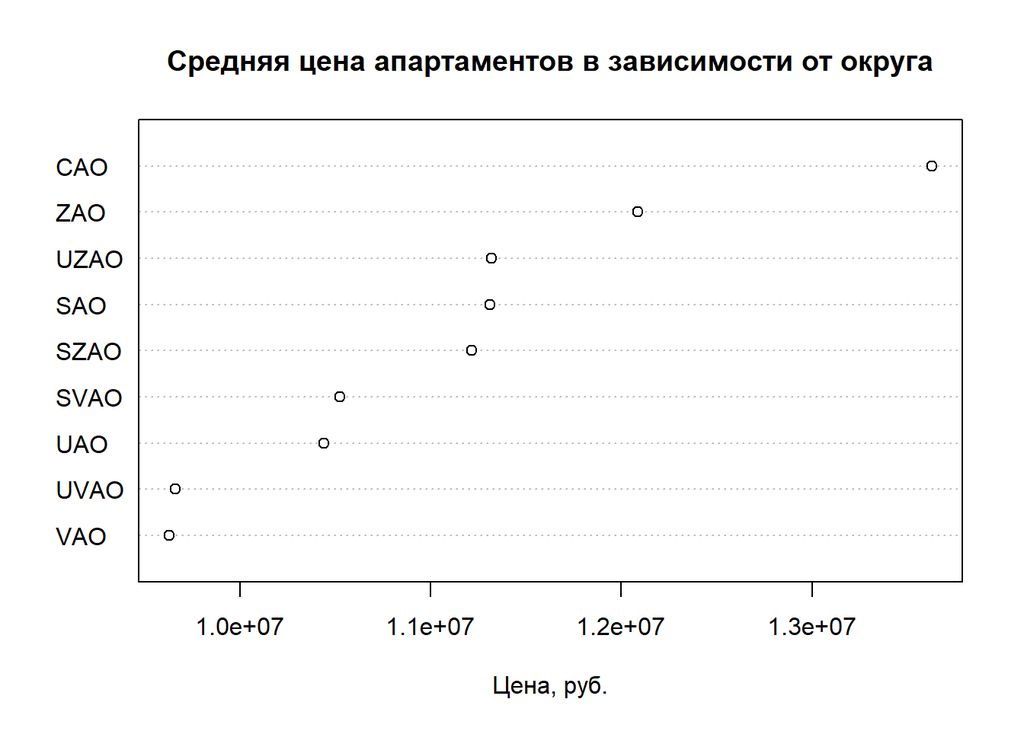

```r
price_means <- tapply(my_data$price, my_data$AO, FUN = mean)
dotchart(as.numeric(price_means[order(price_means)]),
       labels = row.names(price_means[order(price_means)]),
       main = "Средняя цена апартаментов в зависимости от округа",
      xlab = "Цена, руб.")
```

График boxplot + stripchart:

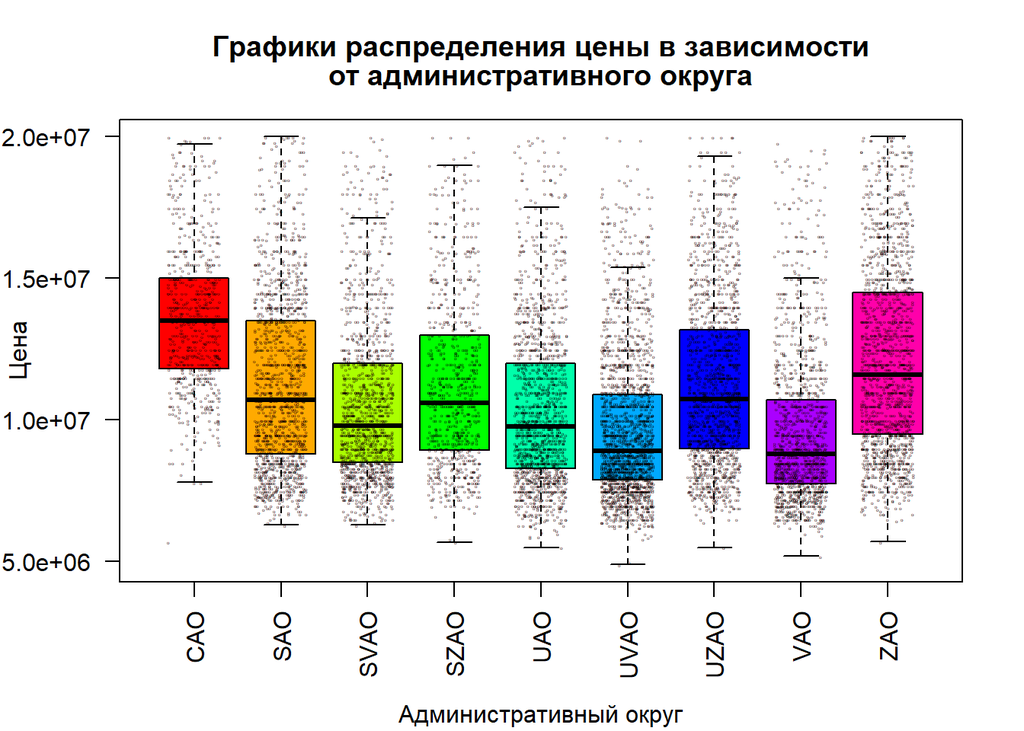

```r
boxplot(my_data$price ~ my_data$AO, main = c("Графики распределения цены в зависимости", "от административного округа"), xlab = "", ylab = "Цена", las = 2, cex=0.5, col = rainbow(length(levels(my_data$AO))), outline = FALSE)
mtext("Административный округ", side = 1, line = 4)
stripchart(my_data$price ~ my_data$AO, vertical = TRUE, method = "jitter", jitter = 0.3, cex = 0.2, pch = "o", col = "black", add = TRUE)
```

# 3. Работа с выбросами с помощью критериев Граббса и Диксона

Главное условие применимости критериев Граббса и Диксона - нормальное распределение данных. Для теста Диксона дополнительное ограничение - размер выборки из отрезка [6, 30].

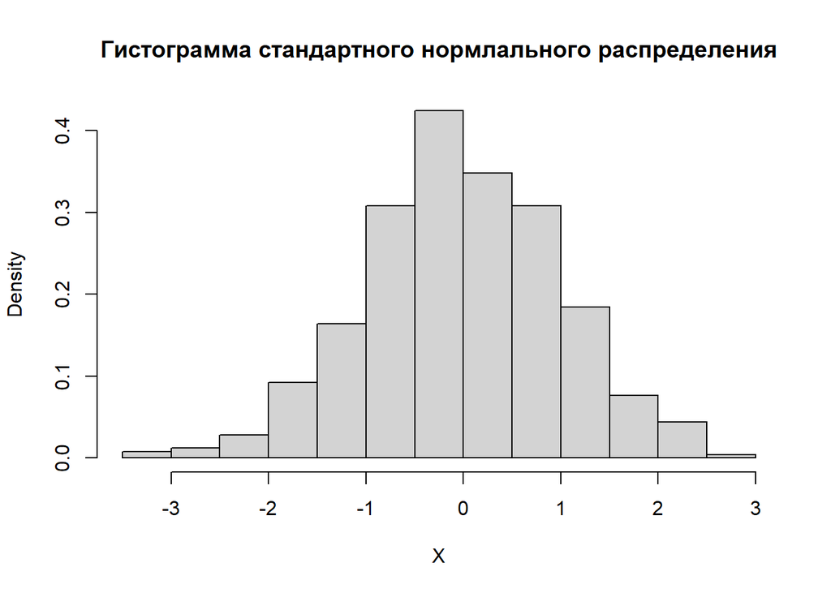

```r
library(outliers)

# устанавливаем seed для воспроизводимости результатов
set.seed(5)

# Генерируем выборку из стандартного нормального распределения размера 500
X <- rnorm(n = 500, mean = 0, sd = 1)

# Гистограмма сгенерированной выборки
hist(X, freq = FALSE, breaks = 20, main = "Гистограмма стандартного нормлального распределения")
```

Проведем тест Граббса для данной выборки:

```r
grubbs.test(X, type = 10)
```

```
##
##  Grubbs test for one outlier
##
## data:  X
## G = 3.4715, U = 0.9758, p-value = 0.1203
## alternative hypothesis: lowest value -3.4980589839012 is an outlier
```

Тест Граббса определил минимальное значение как выброс с уровнем значимости 0.12, хотя вся выборка из нормального распределения (поэтому и уровень значимости довольно высок).

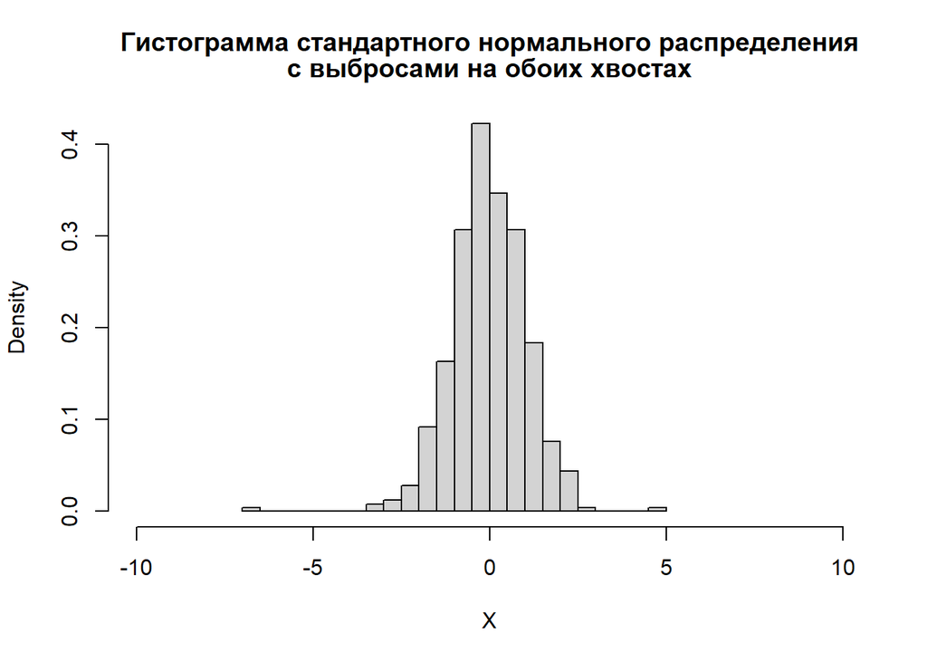

```r
# Исскуственно добавим в выборку два выброса:
X <- append(X, c(5, -7))

hist(X, freq = FALSE, breaks = 20, xlim = c(-10, 10), main = c("Гистограмма стандартного нормального распределения", "с выбросами на обоих хвостах"))
```

Воспользуемся критерием Граббса для определения выбросов:

```r
# Тест Граббса для двухсторонних выбросов
grubbs.test(X, type = 11)
```

```
##
##  Grubbs test for two opposite outliers
##
## data:  X
## G = 11.16171, U = 0.87226, p-value < 2.2e-16
## alternative hypothesis: -7 and 5 are outliers
```

Результат: с помощью критерия Граббса выявлены оба выброса с очень высоким уровнем значимости

Проведем тест Диксона для другой нормально распределенной выборки:

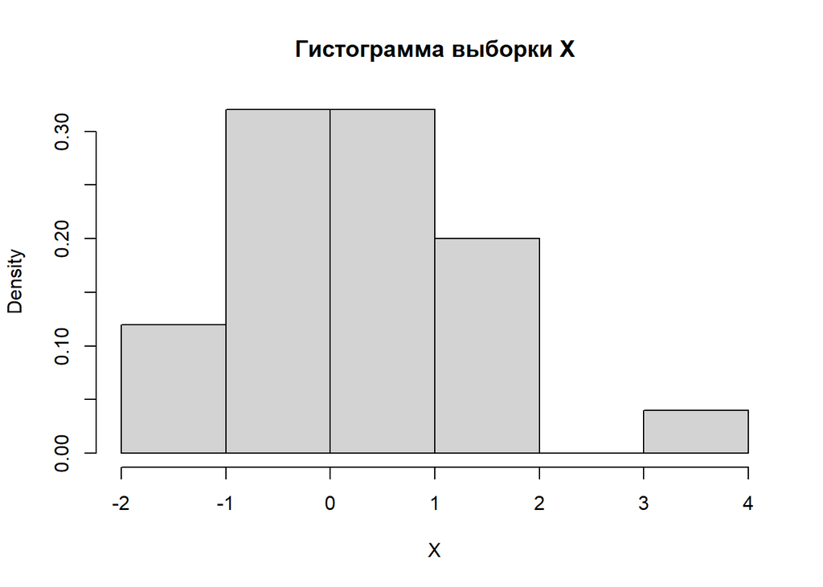

```r
X <- rnorm(25, mean = 0, sd = 1)
hist(X, freq = FALSE, breaks = 5, main = "Гистограмма выборки X")
```

```r
dixon.test(X)
```

```
##
##  Dixon test for outliers
##
## data:  X
## Q = 0.36966, p-value = 0.1747
## alternative hypothesis: highest value 3.40187203166968 is an outlier
```

Внесём выбросы в выборку Х и проведем тест Диксона:

```r
X <- append(X, 5)
dixon.test(X)
```

```
##
##  Dixon test for outliers
##
## data:  X
## Q = 0.5325, p-value = 0.0005753
## alternative hypothesis: highest value 5 is an outlier
```

Значение p-value достаточно мало, чтобы считать значение 5 выбросом.

Попробуем применить данные тесты на выбросы на датасете о апартаментах Москвы. Как уже было сказано, условие применимости тестов Граббса и Диксона - нормальное распределение данных.

В моем датасете подозрительными на нормальность являются признаки цены и площади квартиры.

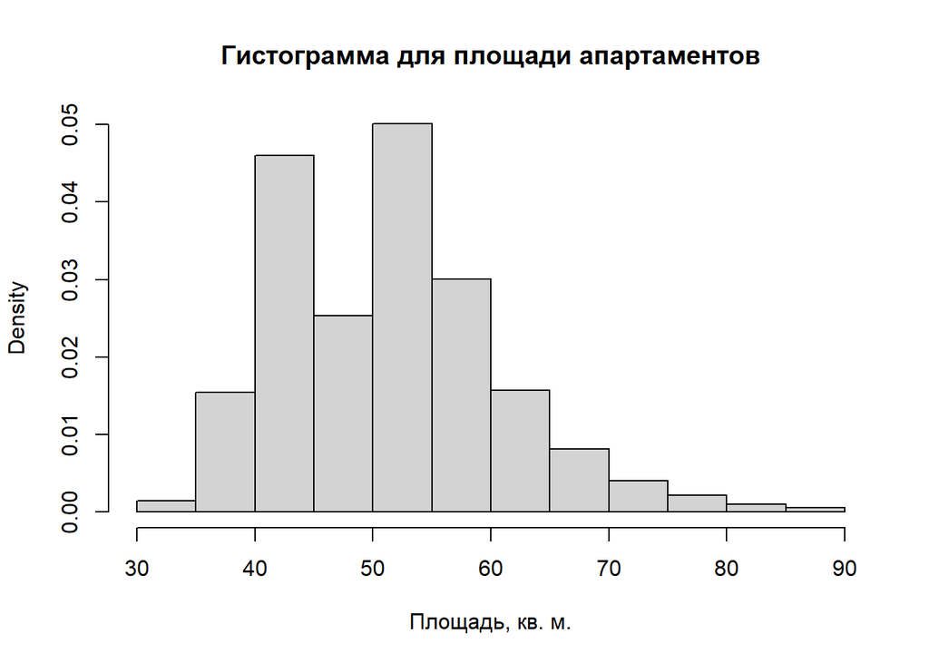

```r
hist(my_data$footage[my_data$rooms == 2], freq = FALSE, breaks = 10, main = "Гистограмма для площади апартаментов", xlab = "Площадь, кв. м.")
```

Гистограмма показывает, что площадь имеет бимодальное распределение, что уже не согласуется с гипотезой о нормальности.

Гистограмма для распределения цены отдельно для каждого округа (суммарно для всех округов распределение цены не симметричное, т.е. не нормальное):

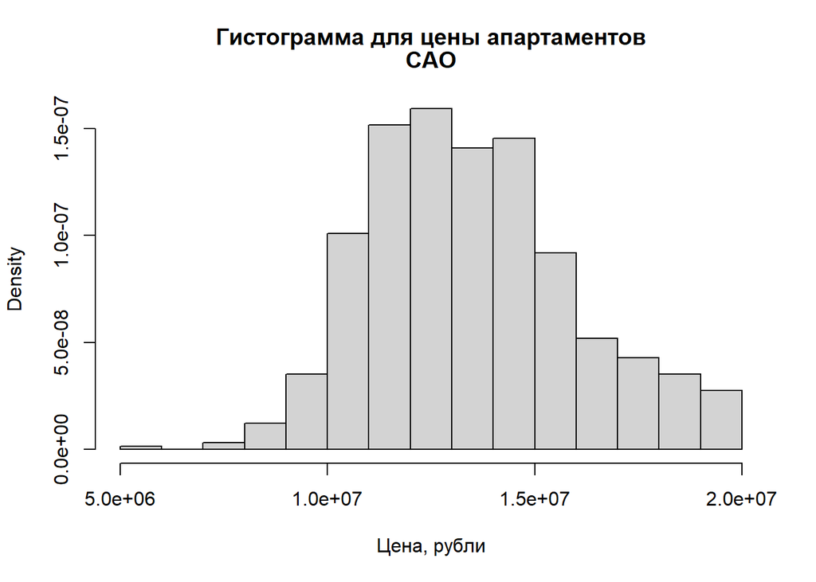

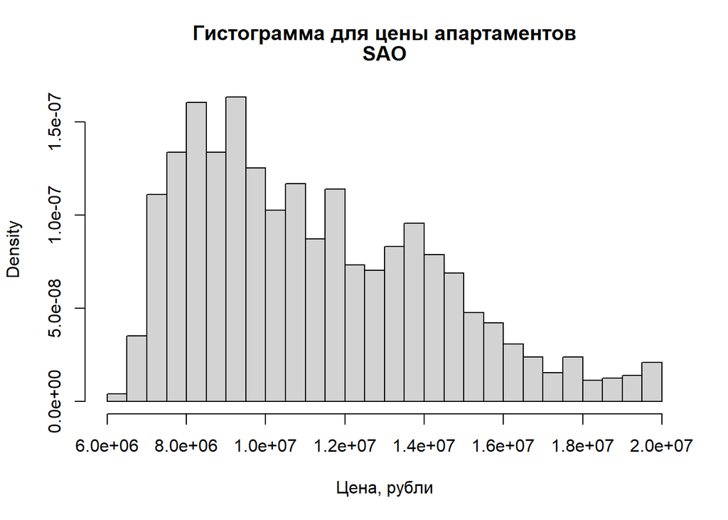

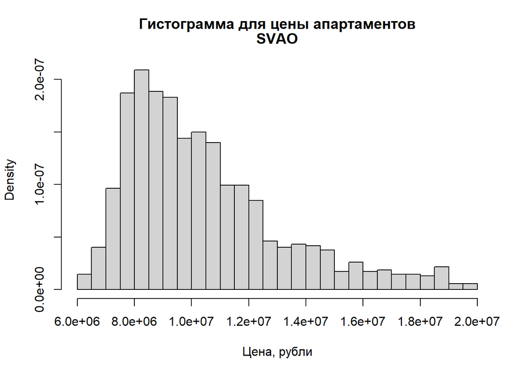

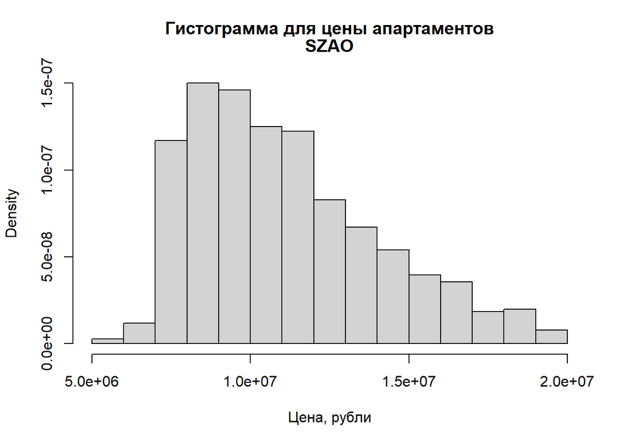

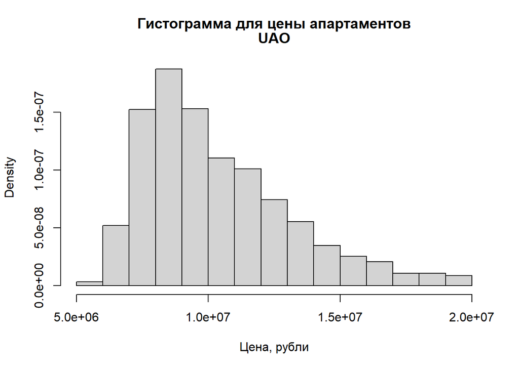

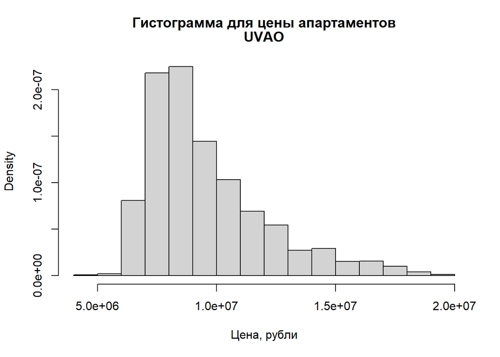

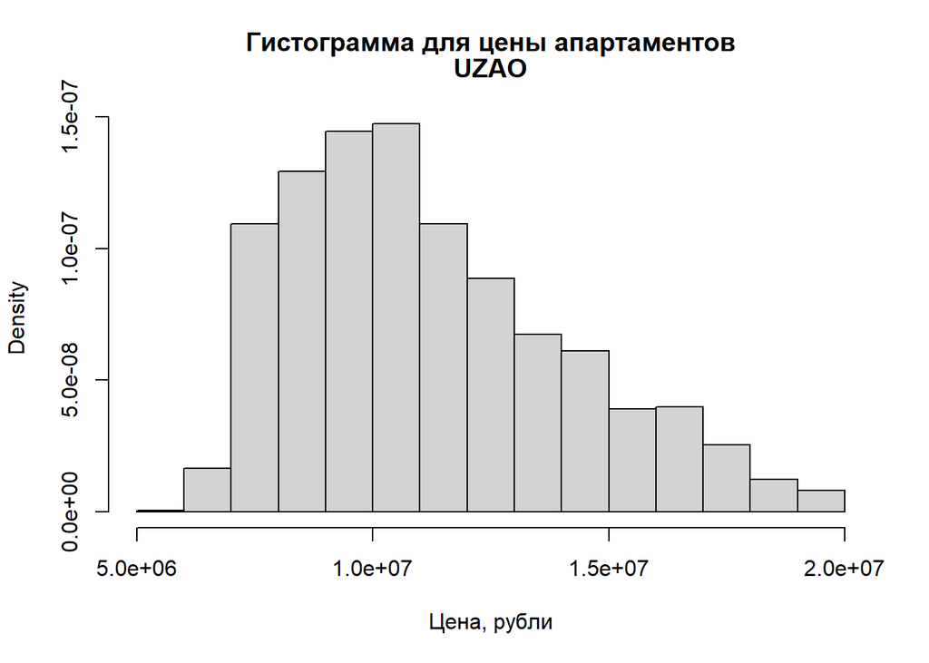

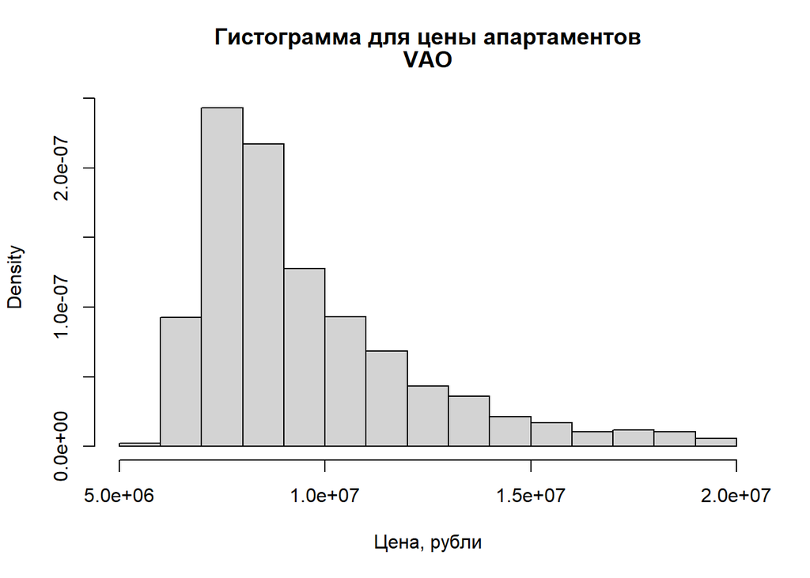

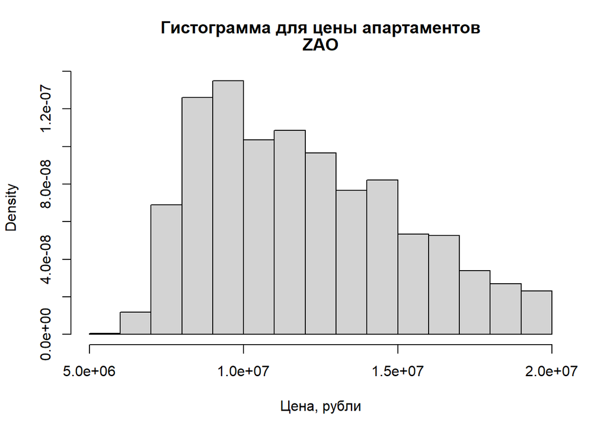

```r
for (ao in levels(my_data$AO)) {
  hist(my_data$price[my_data$AO == ao], freq = FALSE, breaks = 20, main = c("Гистограмма для цены апартаментов", ao), xlab = "Цена, рубли")
}
```

Наиболее похожее на нормальное распределение является распределение цен в округе “CAO”.

Проверим гипотезу о нормальности с помощью метода Шапиро-Уилка:

```r
library(rstatix)

shapiro.test(subset(my_data, AO == "CAO")$price)
```

```
##
##  Shapiro-Wilk normality test
##
## data:  subset(my_data, AO == "CAO")$price
## W = 0.9812, p-value = 1.958e-07
```

Значение p-value < 0.05, => гипотеза о нормальности считается не выполненной для этих данных.

В общем, у меня не получилось найти нормально распределенных признаков в моих данных. Именно поэтому я привел результаты тестов Граббса и Диксона на специально сгенерированной выборке.

# 4. Работа с пропусками в данных

Для работы с пропусками рассмотрим датафрейм, содержащий 1/10 случайных строк из my_data:

```r
data1 <- my_data[sample(1:(length(rownames(my_data))), size = (length(rownames(my_data)) %/% 10)), ]

# сохранили данные в другом датафрейме
data2 <- data1
```

Внесем пропуски в колонки price и footage:

```r
feature_list <- list("price", "footage")

for (feature in feature_list) {
  data1[sample(1:length(rownames(data1)), length(rownames(data1)) %/% 20), feature] <- NA
}
```

Преобразуем столбцы repair и hm к типу factor:

```r
data1$repair <- as.factor(data1$repair)
data1$hm <- as.factor(data1$hm)
```

С помощью функции aregImpute предсказываем пропущенные данные с помощью признаков price, footage, repair, rooms, AO, hm, dist_to_subway, subway_dist_to_center:

```r
library(Hmisc)
impute_arg <- aregImpute(~price + footage + repair + rooms + AO + hm + dist_to_subway + subway_dist_to_center , data = data1, n.impute = 5)
```

```
## Iteration 1
Iteration 2
Iteration 3
Iteration 4
Iteration 5
Iteration 6
Iteration 7
Iteration 8
```

Подсчитаем среднее значение относительной ошибки (отношение разницы между реальными данными и предсказанными к реальным данным):

```r
data1$price[impute_arg$na$price] <- impute_arg$imputed$price[,1]
data1$footage[impute_arg$na$footage] <- impute_arg$imputed$footage[,1]

price_diff <- mapply(abs, data1$price - data2$price)
err_vec <- price_diff / data2$price
mean(err_vec[err_vec != 0])
```

```
## [1] 0.1383013
```

```r
footage_diff <- mapply(abs, data1$footage - data2$footage)
err_vec <- footage_diff / data2$footage
mean(err_vec[err_vec != 0])
```

```
## [1] 0.1115437
```

Получили, что средняя относительная ошибка для предсказания величины price составляет 0.138, а для footage - 0.111.